# Vibe coding example2 問いかけと出力記録

Author

Seiro Ito

Published

October 07, 2026, 05:10 +0900

# Meta prompt

Below is what I asked you in the terminal.

> I am a student who is analyzing data related to education. Find ViveCodingExample2.qmd in this folder. Read the Procedure. Respond to my Instructions and render the file. I will update the file each time I receive your outputs written in the file.

# Procedure

- I will add “Instructions” as you provide “Outputs.”
- You will add outputs right after each instruction. Also add “X+1th query” subsection, “Instructions”, and “Outputs” when you respond to the X-th query.
- When you provide codes, they must be either in R or Python. R is the most preferred language. Use Python only if you cannot get the task done with R.
- Code blocks must not result in a horizontal scroll bar. Use linebreaks.
- Use a Tufte style css. Find the right main text width that is best for viewing.
- Outputs must be succinct. Do not provide any analytical comments. I will do the interpretations. Provide only data related information that is useful in interpreting outputs, and the reason of your choices in creating outputs.

# Instructions and outputs

## 1st query

### Instructions

- I am trying to estimate the mean schooling years of humans.
- This is an average of schooling years of all world population at each point of time.
- Final output is a line plot with a line connecting each points, showing time series changes.
- I also want a regional breakdown of estimates and their plots, a group of lines in a singe figure.
- X axis is calendar years, Y axis is school years. Use colour blind aware colour schemes, as in viridis.
- Find most suitable variables from WB data, UNICEF, DHS or any other authoritative sources.

### outputs

Variables

| Source | Variable | Years | Coverage | Age |
| --- | --- | --- | --- | --- |
| Barro-Lee v3 (`BL_v3_MF.csv`) | `yr_sch` | 1950–2015, every 5 years | 146 countries | 25–64 |
| UNDP HDR 2023/24 (composite indices time series) | `mys_YYYY` | 1990–2022, annual | UNDP world and 6 regional aggregates | 25+ |

Reasons for choices

- Mean years of schooling is published by Barro-Lee and UNDP; WB WDI and UNICEF re-publish these, DHS covers only surveyed countries and years.
- Barro-Lee: longest span; file gives `yr_sch` and population (`pop`, thousands) by country × 10-year age group.
- Barro-Lee world and regional means: population-weighted over countries × age groups 25–64. The file has no 65+ group.
- UNDP: total (both sexes) columns `mys_YYYY` only; `mys_f_*`, `mys_m_*` not used.
- UNDP: annual and more recent; world and regional values are UNDP’s own aggregates (rows `ZZK.WORLD`, `ZZE.AS` … `ZZJ.SSA`), not recomputed.
- Regions are each source’s own grouping: Barro-Lee 7 (incl. “Advanced Economies”), UNDP 6 (developing regions only). Not comparable one-to-one.
- World line in black, regions in viridis (colour-blind safe).

```r
library(dplyr)
library(tidyr)
library(ggplot2)
```

```r
bl_url <- paste0(
  "https://barrolee.github.io/",
  "BarroLeeDataSet/BLData/BL_v3_MF.csv")
bl <- read.csv(bl_url)
```

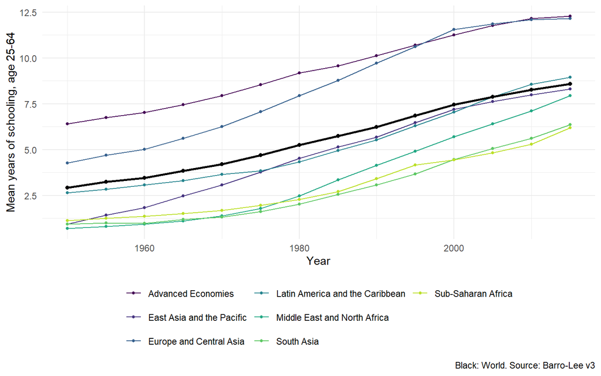

```r
bl25 <- bl |> filter(agefrom >= 25)
bl_reg <- bl25 |>
  group_by(year, region = region_code) |>
  summarise(mys = weighted.mean(yr_sch, pop),
            .groups = "drop")
bl_wld <- bl25 |>
  group_by(year) |>
  summarise(mys = weighted.mean(yr_sch, pop)) |>
  mutate(region = "World")
ggplot(bl_reg, aes(year, mys, colour = region)) +
  geom_line() +
  geom_point(size = 1) +
  geom_line(data = bl_wld, colour = "black",
            linewidth = 1) +
  geom_point(data = bl_wld, colour = "black") +
  scale_colour_viridis_d(end = .9) +
  labs(x = "Year",
       y = "Mean years of schooling, age 25-64",
       colour = NULL,
       caption = "Black: World. Source: Barro-Lee v3") +
  theme_minimal() +
  theme(legend.position = "bottom") +
  guides(colour = guide_legend(nrow = 3))
```

```r
undp_url <- paste0(
  "https://hdr.undp.org/sites/default/files/",
  "2023-24_HDR/HDR23-24_Composite_indices_",
  "complete_time_series.csv")
undp <- read.csv(undp_url,
                 fileEncoding = "latin1")
```

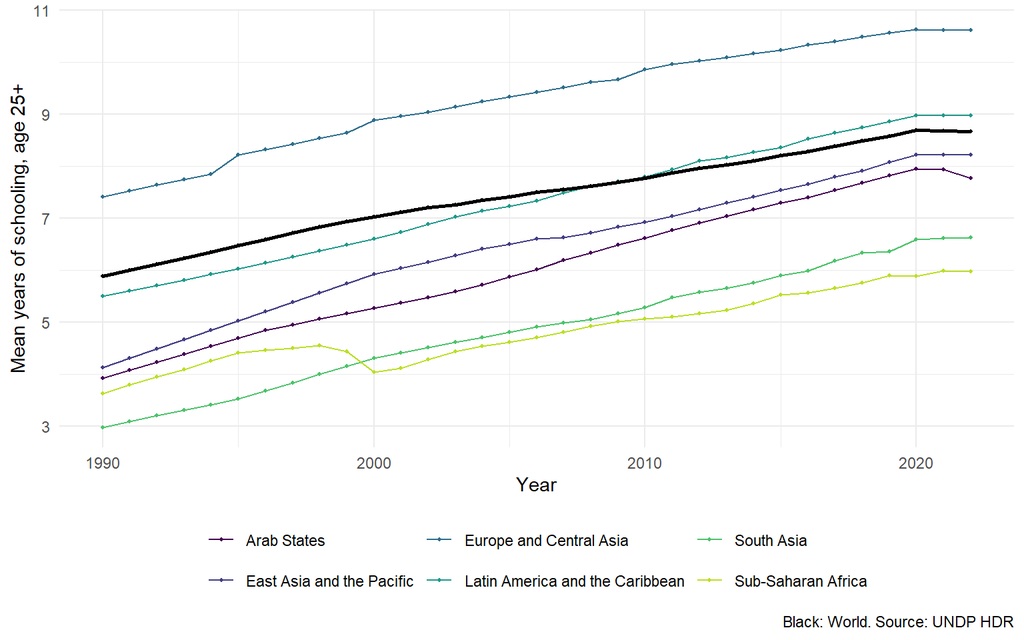

```r
agg <-c("ZZE.AS", "ZZF.EAP", "ZZG.ECA",
         "ZZH.LAC", "ZZI.SA", "ZZJ.SSA",
         "ZZK.WORLD")
un <- undp |>
  filter(iso3 %in% agg) |>
  select(country,
         matches("^mys_[0-9]{4}$")) |>
  pivot_longer(-country,
               names_to = "year",
               names_prefix = "mys_",
               values_to = "mys") |>
  mutate(year = as.integer(year))
un_wld <- un |> filter(country == "World")
un_reg <- un |> filter(country != "World")
ggplot(un_reg, aes(year, mys, colour = country)) +
  geom_line() +
  geom_point(size = .8) +
  geom_line(data = un_wld, colour = "black",
            linewidth = 1) +
  geom_point(data = un_wld, colour = "black",
             size = .8) +
  scale_colour_viridis_d(end = .9) +
  labs(x = "Year",
       y = "Mean years of schooling, age 25+",
       colour = NULL,
       caption = "Black: World. Source: UNDP HDR") +
  theme_minimal() +
  theme(legend.position = "bottom") +
  guides(colour = guide_legend(nrow = 2))
```

Data notes

```r
tibble(
  item = c("Barro-Lee countries",
           "Barro-Lee years",
           "Barro-Lee missing yr_sch (25-64)",
           "Barro-Lee missing pop (25-64)",
           "UNDP aggregate rows",
           "UNDP years",
           "UNDP missing mys (aggregates)"),
  value = c(n_distinct(bl$BLcode),
            paste(range(bl$year),
                  collapse = "-"),
            sum(is.na(bl25$yr_sch)),
            sum(is.na(bl25$pop)),
            n_distinct(un$country),
            paste(range(un$year),
                  collapse = "-"),
            sum(is.na(un$mys)))
) |> knitr::kable()
```

| item | value |
| --- | --- |
| Barro-Lee countries | 146 |
| Barro-Lee years | 1950-2015 |
| Barro-Lee missing yr_sch (25-64) | 0 |
| Barro-Lee missing pop (25-64) | 0 |
| UNDP aggregate rows | 7 |
| UNDP years | 1990-2022 |
| UNDP missing mys (aggregates) | 0 |

## 2nd query